# DataAnalysis

Nikola_Stankovic

## Data Analysis

Import the dataset:

```r
fdata <- read.csv("http://archive.ics.uci.edu/ml/machine-learning-databases/forest-fires/forestfires.csv")
#fdata <- read.csv("C:/CKME136/Forest Fires/forestfires.csv")
str(fdata)
```

```
## 'data.frame':    517 obs. of  13 variables:
##  $ X    : int  7 7 7 8 8 8 8 8 8 7 ...
##  $ Y    : int  5 4 4 6 6 6 6 6 6 5 ...
##  $ month: Factor w/ 12 levels "apr","aug","dec",..: 8 11 11 8 8 2 2 2 12 12 ...
##  $ day  : Factor w/ 7 levels "fri","mon","sat",..: 1 6 3 1 4 4 2 2 6 3 ...
##  $ FFMC : num  86.2 90.6 90.6 91.7 89.3 92.3 92.3 91.5 91 92.5 ...
##  $ DMC  : num  26.2 35.4 43.7 33.3 51.3 ...
##  $ DC   : num  94.3 669.1 686.9 77.5 102.2 ...
##  $ ISI  : num  5.1 6.7 6.7 9 9.6 14.7 8.5 10.7 7 7.1 ...
##  $ temp : num  8.2 18 14.6 8.3 11.4 22.2 24.1 8 13.1 22.8 ...
##  $ RH   : int  51 33 33 97 99 29 27 86 63 40 ...
##  $ wind : num  6.7 0.9 1.3 4 1.8 5.4 3.1 2.2 5.4 4 ...
##  $ rain : num  0 0 0 0.2 0 0 0 0 0 0 ...
##  $ area : num  0 0 0 0 0 0 0 0 0 0 ...
```

```r
nrow(fdata)
```

```
## [1] 517
```

```r
ncol(fdata)
```

```
## [1] 13
```

```r
names(fdata)
```

```
##  [1] "X"     "Y"     "month" "day"   "FFMC"  "DMC"   "DC"    "ISI"
##  [9] "temp"  "RH"    "wind"  "rain"  "area"
```

Check for missing values:

```r
(lapply (fdata, function (x) which (is.na (x))))
```

```
## $X
## integer(0)
##
## $Y
## integer(0)
##
## $month
## integer(0)
##
## $day
## integer(0)
##
## $FFMC
## integer(0)
##
## $DMC
## integer(0)
##
## $DC
## integer(0)
##
## $ISI
## integer(0)
##
## $temp
## integer(0)
##
## $RH
## integer(0)
##
## $wind
## integer(0)
##
## $rain
## integer(0)
##
## $area
## integer(0)
```

Almost 50% of the area data has zeroes. As per the article these are valid as they represent small fires < 100 m2:

```r
zeroes <- (subset(fdata, fdata$area==0))
(nrow(zeroes) / nrow(fdata))
```

```
## [1] 0.4777563
```

Data is very skewed to the right as per histogram:

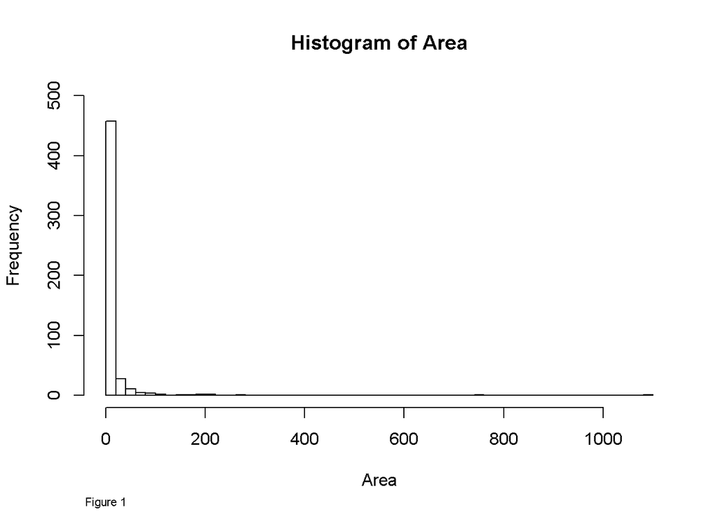

```r
hist((fdata$area),40, ylim = c(0, 500), xlab = 'Area', main = 'Histogram of Area')
mtext(c("Figure 1"),side=1,line=4,at=c(0,0), cex = 0.7)
```

Transform area to log function to improve linear relationship with predictors

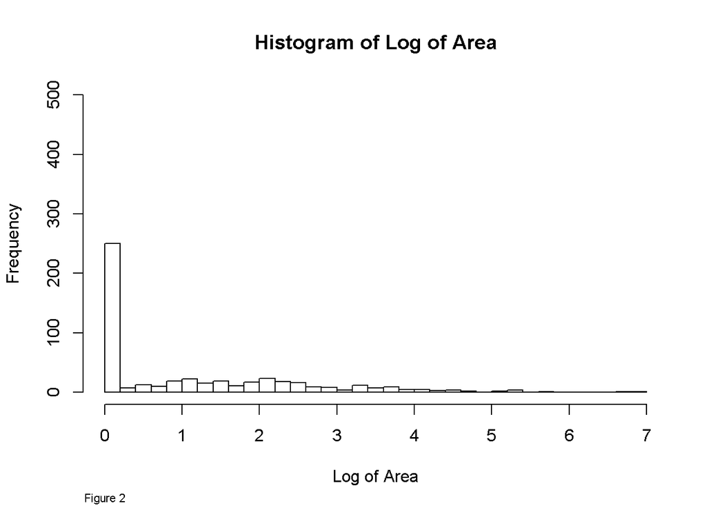

```r
fdata <- within(fdata, {arealog <- log(area + 1)})
hist((fdata$arealog),40, ylim = c(0, 500), xlab = 'Log of Area',  main = 'Histogram of Log of Area')
mtext(c("Figure 2"),side=1,line=4,at=c(0,0), cex = 0.7)
```

Correlation plot with actual numeric correlation

```r
panel.pearson <- function(x, y, ...) {
  horizontal <- (par("usr")[1] + par("usr")[2]) / 2
  vertical <- (par("usr")[3] + par("usr")[4]) / 2
  text(horizontal, vertical, format((cor(x,y)), digits=2))
}
```

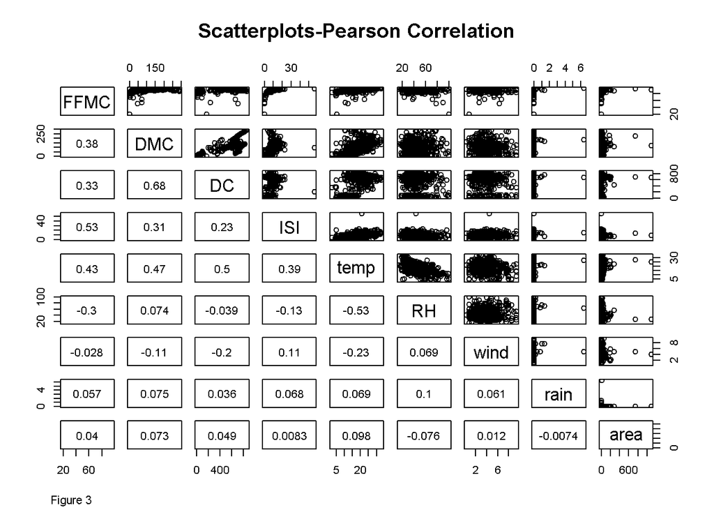

```r
pairs(fdata[,5:13], lower.panel=panel.pearson, main = "Scatterplots-Pearson Correlation")
mtext(c("Figure 3"),side=1,line=4,at=c(0,0), cex = 0.7)
```

Scatter plots for each numeric variable individually:

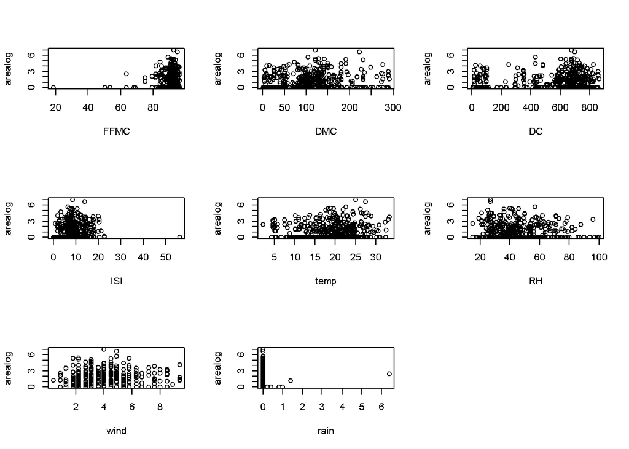

```r
par(mfrow=c(3,3))
plot(arealog ~ FFMC + DMC + DC + ISI + temp + RH + wind + rain,
     data = fdata)
par(mfrow=c(1,1))
```

Plotting packages:

```r
install.packages('ggplot2',repos = "http://cran.rstudio.com/")
library(ggplot2)
library(grid)
library(gridExtra)
```

Area per month box plot

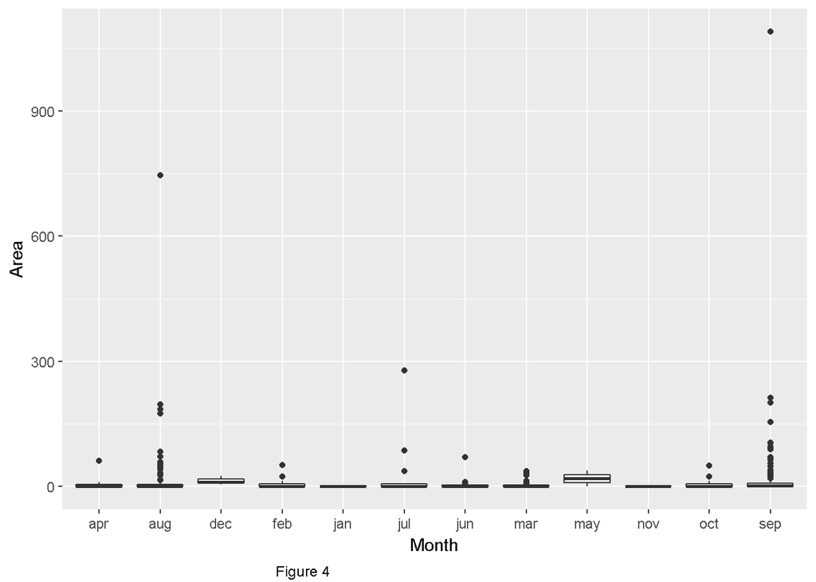

```r
grid.arrange(qplot(x = month, xlab = "Month", y = area, ylab =  "Area"
, data = fdata, geom = 'boxplot'), bottom = textGrob("Figure 4", x = 1, hjust = 10, gp = gpar(fontsize = 9)))
```

There are a couple of outliers in the box plot above, but I am keeping them as that is real data

Group months into seasons:

```r
fdata$season <- rep("spring", nrow(fdata))
for (i in 1:nrow(fdata)){
  if (fdata$month[i] %in% c("feb","jan","dec")) fdata$season[i] <- "winter"
  if (fdata$month[i] %in% c("oct","nov","sep")) fdata$season[i] <- "autumn"
  if (fdata$month[i] %in% c("aug","jul","jun")) fdata$season[i] <- "summer"
}
fdata$season <- as.factor(fdata$season)
```

Area per season box plot:

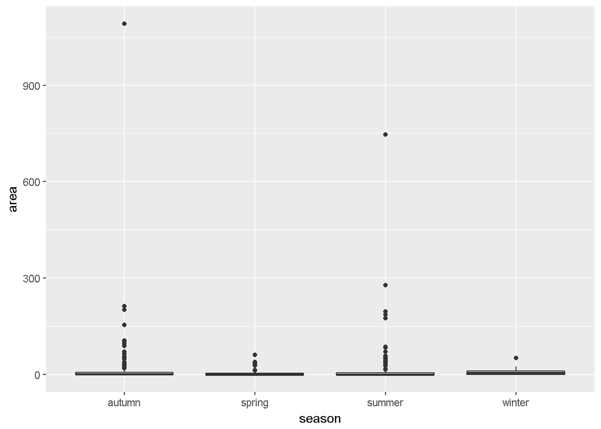

```r
qplot(x = season, y = area , data = fdata, geom = 'boxplot', coord_cartesian(ylim = c(-2,8)))
```

Factor days in weekdays vs weekend classes

```r
fdata$wday <- rep("weekend", nrow(fdata))
for (i in 1:nrow(fdata)){
  if (fdata$day[i] %in% c("mon","tue","wed","thu","fri")) fdata$wday[i] <- "weekday"
}
fdata$wday <- as.factor(fdata$wday)
summary(fdata$wday)
```

```
## weekday weekend
##     338     179
```

Convert 9 X 9 grid to 3 X 3 grid

```r
fdata$X <- as.character(fdata$X)
fdata$Y <- as.character(fdata$Y)
fdata$XY <- with(fdata, paste(X, Y))
for (i in 1:nrow(fdata)){
  if (fdata$XY[i] %in% c("1 1","2 1","3 1","1 2","2 2","3 2","1 3","2 3","3 3")) fdata$XY[i] <- "one"
  if (fdata$XY[i] %in% c("1 4","2 4","3 4","1 5","2 5","3 5","1 6","2 6","3 6")) fdata$XY[i] <- "two"
  if (fdata$XY[i] %in% c("1 7","2 7","3 7","1 8","2 8","3 8","1 9","2 9","3 9")) fdata$XY[i] <- "three"
  if (fdata$XY[i] %in% c("4 1","5 1","6 1","4 2","5 2","6 2","4 3","5 3","6 3")) fdata$XY[i] <- "four"
  if (fdata$XY[i] %in% c("4 4","5 4","6 4","4 5","5 5","6 5","4 6","5 6","6 6")) fdata$XY[i] <- "five"
  if (fdata$XY[i] %in% c("4 7","5 7","6 7","4 8","5 8","6 8","4 9","5 9","6 9")) fdata$XY[i] <- "six"
  if (fdata$XY[i] %in% c("7 1","8 1","9 1","7 2","8 2","9 2","7 3","8 3","9 3")) fdata$XY[i] <- "seven"
  if (fdata$XY[i] %in% c("7 4","8 4","9 4","7 5","8 5","9 5","7 6","8 6","9 6")) fdata$XY[i] <- "eight"
  if (fdata$XY[i] %in% c("7 7","8 7","9 7","7 8","8 8","9 8","7 9","8 9","9 9")) fdata$XY[i] <- "nine"
}
fdata$XY <- as.factor(fdata$XY)
str(fdata)
```

```
## 'data.frame':    517 obs. of  17 variables:
##  $ X      : chr  "7" "7" "7" "8" ...
##  $ Y      : chr  "5" "4" "4" "6" ...
##  $ month  : Factor w/ 12 levels "apr","aug","dec",..: 8 11 11 8 8 2 2 2 12 12 ...
##  $ day    : Factor w/ 7 levels "fri","mon","sat",..: 1 6 3 1 4 4 2 2 6 3 ...
##  $ FFMC   : num  86.2 90.6 90.6 91.7 89.3 92.3 92.3 91.5 91 92.5 ...
##  $ DMC    : num  26.2 35.4 43.7 33.3 51.3 ...
##  $ DC     : num  94.3 669.1 686.9 77.5 102.2 ...
##  $ ISI    : num  5.1 6.7 6.7 9 9.6 14.7 8.5 10.7 7 7.1 ...
##  $ temp   : num  8.2 18 14.6 8.3 11.4 22.2 24.1 8 13.1 22.8 ...
##  $ RH     : int  51 33 33 97 99 29 27 86 63 40 ...
##  $ wind   : num  6.7 0.9 1.3 4 1.8 5.4 3.1 2.2 5.4 4 ...
##  $ rain   : num  0 0 0 0.2 0 0 0 0 0 0 ...
##  $ area   : num  0 0 0 0 0 0 0 0 0 0 ...
##  $ arealog: num  0 0 0 0 0 0 0 0 0 0 ...
##  $ season : Factor w/ 4 levels "autumn","spring",..: 2 1 1 2 2 3 3 3 1 1 ...
##  $ wday   : Factor w/ 2 levels "weekday","weekend": 1 1 2 1 2 2 1 1 1 2 ...
##  $ XY     : Factor w/ 7 levels "eight","five",..: 1 1 1 1 1 1 1 1 1 1 ...
```

Test for multicollinearity; VIF value greater than 5 indicates multicollinearity between predictor

```r
fdata.vif <- fdata[c(5:12)]
install.packages('usdm',repos = "http://cran.rstudio.com/")
library(usdm)
(vif_output <- vif(fdata.vif))
```

```
##   Variables      VIF
## 1      FFMC 1.695255
## 2       DMC 2.330688
## 3        DC 2.078205
## 4       ISI 1.578258
## 5      temp 2.661897
## 6        RH 1.899989
## 7      wind 1.140610
## 8      rain 1.044801
```

```r
write.table(vif_output, "C:/CKME136/Forest Fires/Vifdata.txt", sep="\t", row.names = F)
```

The highest VIF value is 2.66, means no multicollinearity. No need to remove any numeric variables

SAVE DATASET IN A TEMPORARY DATA FRAME FOR THE LATER ANALYSIS

```r
fdatatemp <- fdata
save(fdatatemp,file="C:/CKME136/Forest Fires/fdata.RDa")
```